# act_report

## Report: act_report - WeRateDogs

As part of the fulfillment of Udacity's Data analyst nano degree, i worked on a dataset from WeRateDogs Twitter Archive, a page that tweets humorous reviews of cute looking dogs. There was no particular objective in mind at the beginning of the analysis, i simply intented to flex my data wrangling skills, explore and see if there are any interesting insights to learn from the data, Thankfully there were quite a few!

1. Most of the tweets were made from an iphone. This is interesting, an indicator that the administrator of the page uses an iPhone. However there were a few times Twitter Web and Tweetdeck were used.

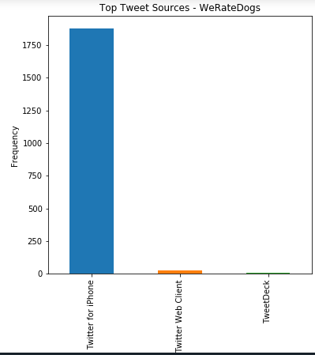

1. A lot of dog breeds were not specified, unfortunately. However i was very interested in how frequently the specified breeds occurred in the dataset. Golden retriever dogs were the most frequrntly rated breed of dog, however it is difficult to pick a clear winner here given the high number of unspecified breeds as seen below. I have also inserted a random picture of one the golden retrievers

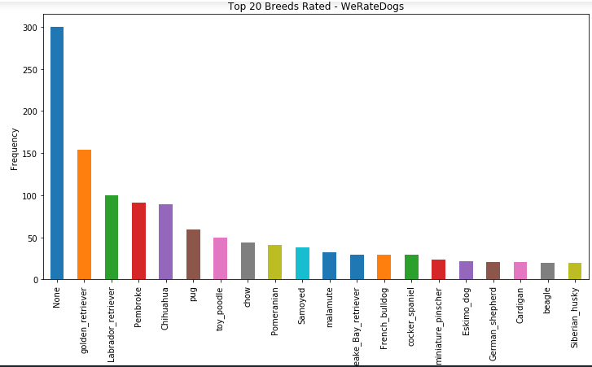

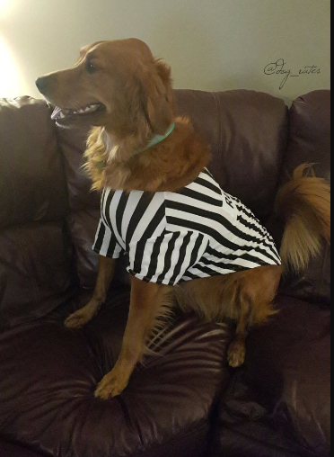

1. The Soft coated wheaten terrier dogs had the highest ratings on average, Leap frogging uncategorized dog breeds. However, it is still not easy to pick a winner here until we can somehow get more data on the other dog breeds

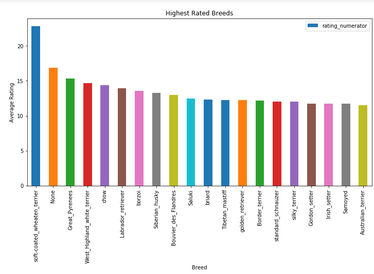